# WINE

### TOP 5 WINE MANUFACTURER COUNTRIES

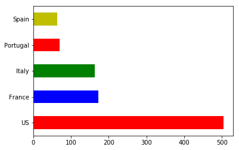

```python
top_pro = wine_df.country.value_counts()
top_5_pro = top_pro.iloc[0:5]
top_5_pro.plot(kind='barh', color=['r','b','g','r','y'])
```

```python
## MOST TOP 5 WINE VARIETIES
```

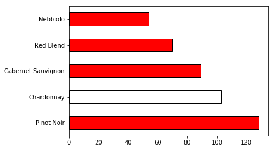

```python
top_5_variety = wine_df.variety.value_counts().head()
top_5_variety.plot(kind='barh', color=['r', 'w','r','r','r'], edgecolor = 'black')
```

```python
wine_df.isnull().sum()
```

[output not shown]

[output not shown]

ALTHOUGH THERE'S A GOOD AMOUNT OF MISSING VALUE, IT DID NOT AFFECT GREATLY OUR EDA.

but if we had to fix the columns with missing values I think K nearest neighbor will appropriate in this case. because, columns like region_1 and region_2 have a very close relationship with the country, province, description and some other coolums. however for the missing value in price column I was thinking of interpolate() method of filling or using the average price of their scoring_scale.

```python
# LET'S GENERATE SOME WORD CLOUD FOR PROVINCES AND VARIETIES
```

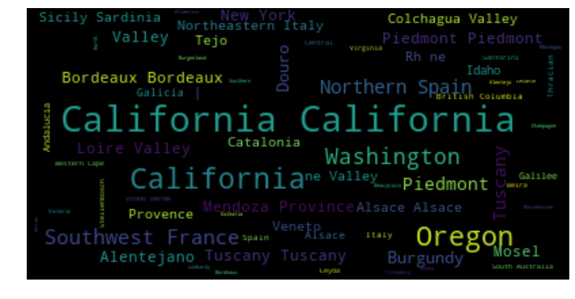

```python
province = list(wine_df.province) #CREATE A LIST OF PROVINCES
province = ' '.join(province)     # JOIN THE PROVINCES TO GET ONE STRING


plt.figure(figsize=(12,18))       #SET THE CANVAS TO SUIT OUR VIZ

wordcloud = WordCloud().generate(province)      #CREATE A WORDCLOUD AND LET THE MODULE DECIDE THE WIDTH AND HEIGHT
plt.imshow(wordcloud, interpolation='bilinear')
plt.axis('off')
plt.margins(x=0, y=0)
```

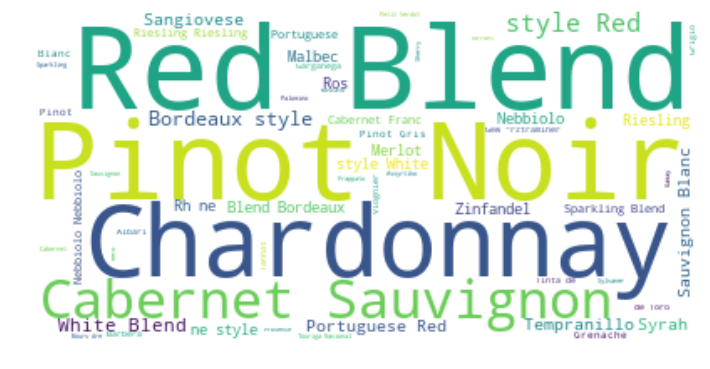

```python
variety = list(wine_df.variety)
variety = ' '.join(variety)

plt.figure(figsize=(12,18))
wordcloud = WordCloud(background_color='white').generate(variety)
plt.imshow(wordcloud, interpolation='bilinear')
plt.axis('off')
plt.margins(x=0, y=0)
```